# CodesRUs Final Report

March 9, 2022

# Modelling Shot Success Rate and Win Probabilities in Soccer

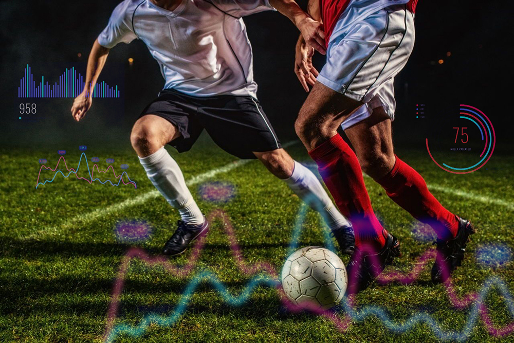

## Chapter 1: Introduction

Soccer is the most watched sport in the world and is a business for teams worth hundreds of millions of dollars. In fact, 43% of the sports viewers in the World are interested in watching soccer, compared to 37% from Basketball viewers; and the FIFA World Cup Media rights income budgeted a whopping total of $3.0 billion USD for this event alone. (Nielson Sports, 2018) As a result, clubs put a great deal of time and resources towards achieving success. This includes collecting ever increasing amounts of data about their team’s performances and those of others. Unfortunately, most of these data sets are not publicly available. There are still small data sets that have become publicly available, such as this one obtained by Luca Pappalardo on Figshare. From this small data set we hope to gain some insight into the game and an understanding of how data is coming to be used in soccer.

## Chapter 2: Data Set Overview

The dataset contains all matches played in Europe’s top five leagues during the 2017/2018 season (380 matches per league for a total of 1900 matches, producing 643,149 match events), the 2016 European Championship (51 matches, producing 78,139 match events), and the 2018 World Cup (64 matches, 101,758 match events). The data was imported by league and then compiled into a single data frame, giving a total of 3,251,294 events and 19 variables. This data was originally released by Wyscout.

One variable we are interested in looking at is the distance of assists and key passes and whether this plays a role in the success of the pass and whether it results in a successful shot on goal or not. We have to calculate distance for each event using the x,y-coordinates given in the data set. To do this we assumed field dimensions of 120 yards in length of 75 yards wide. This is the average size of a soccer pitch. We then are able to calculate event distances in yards instead of percentages. If the x and y coordinates in percentage were used we’d get a distorted distance since in reality a soccer field is not square. In this report x & y-coordinates are displayed as percentages, while event distance is displayed in yards so results are not distorted.

## Chapter 3: Event Vizualization

### 3.1 Understanding the Field

To understand our data, we needed to first understand how the field is set up. The field is set up so that the length is given by the x-coordinate, and the width is given by the y-coordinate. Each coordinate is given as a percentage. Events are always oriented so that the attacking team is going from left to right.

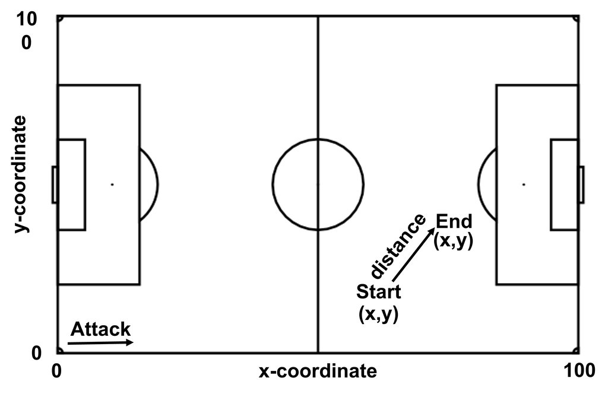

**Figure 1.** Pitch schematic showing direction of attack and event x,y-coordinate example.

### 3.2 Event Visualization

#### 3.2.1 Visualizing Field Locations

Using the ggsoccer library to plot event data on an image of a pitch and bordering the x and y axis with event density plots we were quickly able to understand how each event is distributed on the pitch, shown in Figure 2. Several observations can be made from this visualization. First, the x & y-coordinates for both key passes and assists are multimodal and appear to be symmetric across the y=50 line. This makes sense as teams try to attack down both sides of the field. With this data being an average over so many games getting a symmetric split between the two sides of the field is expected. This symmetry could be a factor that varies from team to team, however. Second, the x & y-coordinate distributions for shots and goals is much closer to normal. The exception being the x-coordinate for shots which is bimodal. This is interesting because it indicates that a significant portion of shots are taken farther away from goal, however, very few goals are scored from these shots. Despite this, players still seem to take these shots.

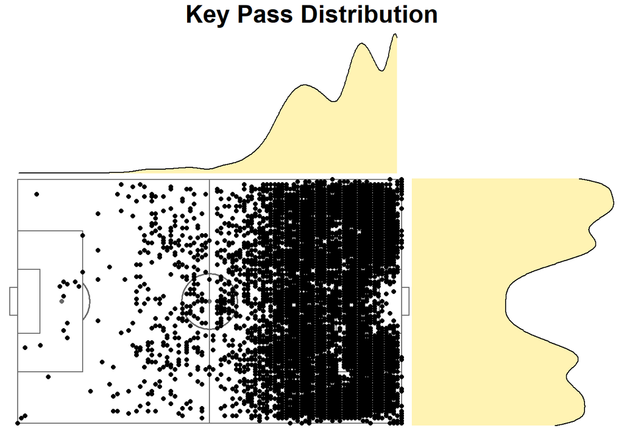

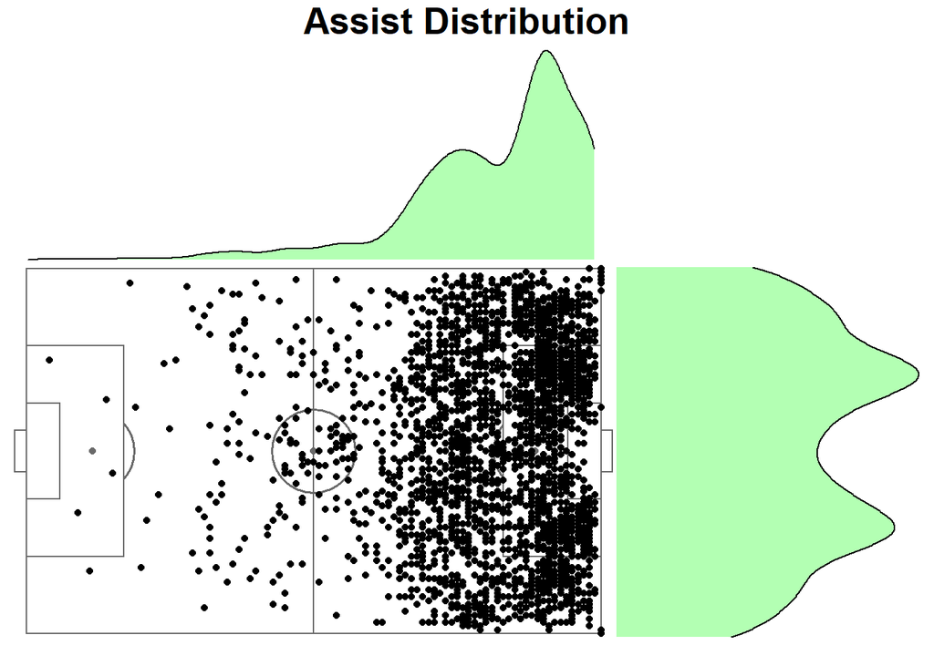

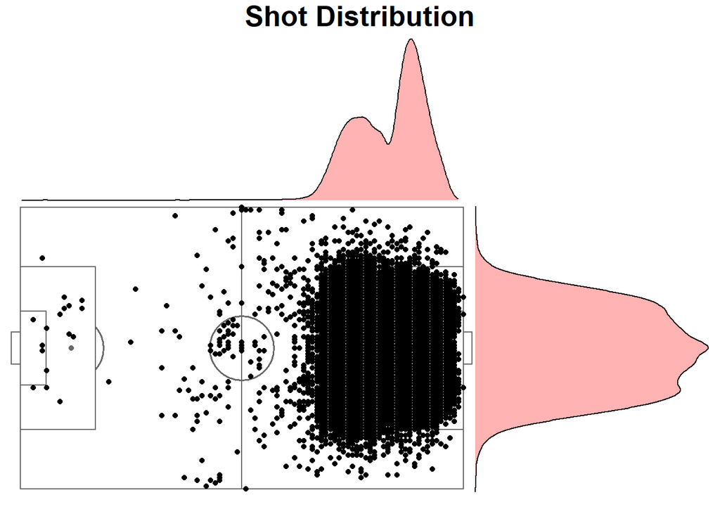

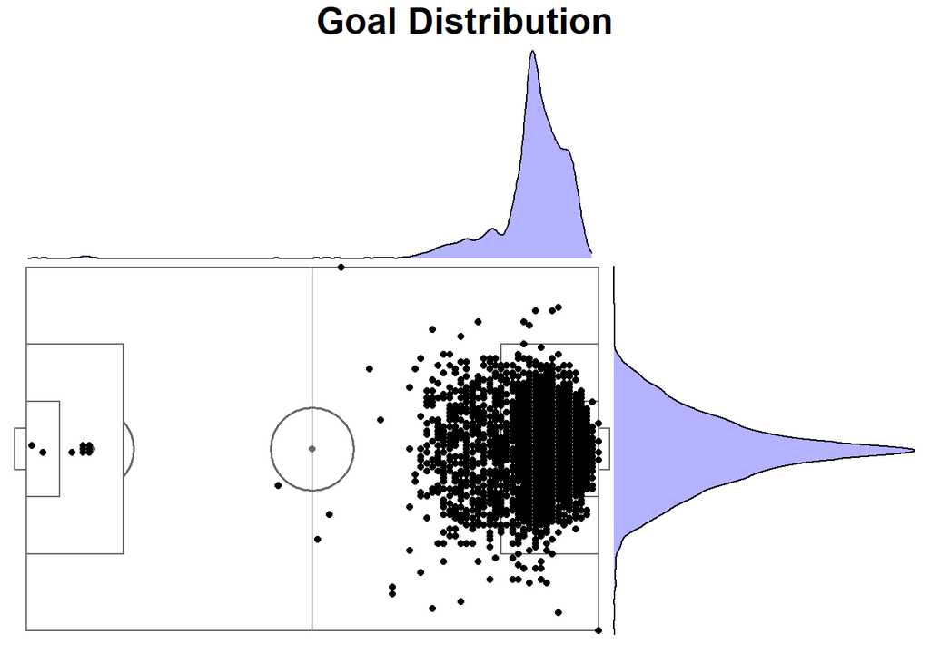

**Figure 2.** Event field locations and x & y-coordinate density plots for (Top Left) Key Passes, (Top Right) Assists, (Bottom Left) Shots, and (Bottom Right) Goals.

#### 3.2.2 Event Distance Distributions

The distance distributions for key passes and assists are displayed in Figure 3. Both show fairly normal distributions, despite the fact that neither the x,y-coordinates for these two events show normal distributions. The distances of shots and goals were not examined as the x & y end coordinates given in the dataset were found to be inaccurate.

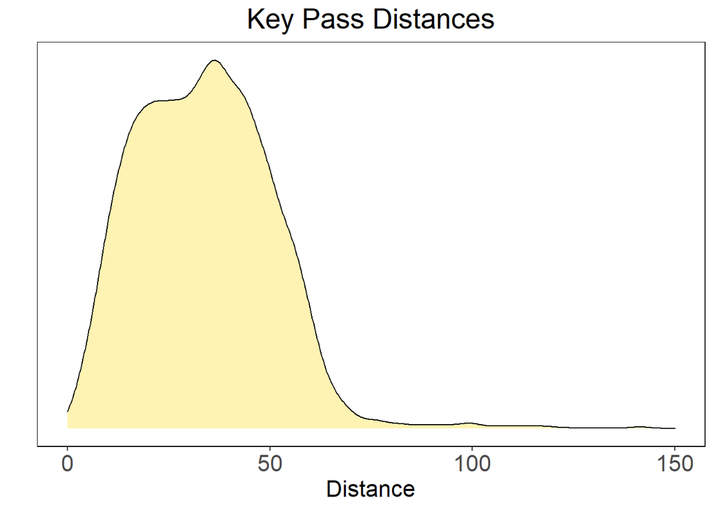

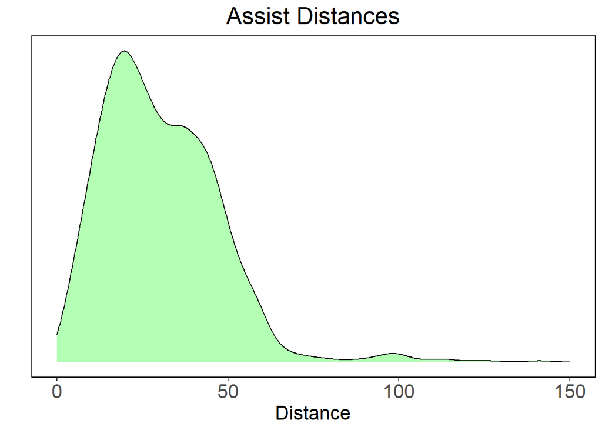

**Figure 3.** Event distance for (Left) Key Passes and (Right) Assists.

## Chapter 4: Determining Goal Probabilities

### Given the variables that describe the (X, Y) coordinates of the beginning and end of key events (shots, assists, key passes), which configuration of the variables result in the best fitting model that gives the probability of a shot on goal being successful?

In the midterm project, we came up with a logit model to try and predict the probabilities of scoring a goal, given the (x, y) starting coordinates on the field, the (x, y) ending coordinates, as well as the distance travelled by the ball.

There were some issues with this approach:

1. There was high multicollinearity between the terms in the model. For example, “Distance” is dependent on the (x, y) coordinates for starting and ending plays.
2. The data from the independent variables was not centered.
3. The Betas obtained at the summary of the model were not the probabilities of scoring a goal; rather, they were the logit coefficients of the model. We had not seen the technique to convert the logit coefficients to actual probabilities (i.e., fitted values), so we were unable to propose a better model.
4. From the previous point, it is then necessary to build an additional vector in the database that includes reasonable values of the probabilities of scoring a goal. We then need to build an additional model that results in Betas expressed as probabilities of scoring a goal.

With this, we did 4 things:

1. Checked that the selection of observations is balanced: similar number of observations for success as for failure (1 or 0 in “Success” vector). These counts resulted in 30,475 observations of success vs 33,786 observations of failure. It’s more or less balanced, so no further action was taken.
2. We centered the values of independent variables: subtract the mean from of each variable from each observation of that variable.
3. We built new logit models, considering interaction terms.
4. We evaluated the logit models based on BIC and VIF criteria, and selected the one that had no multicollinearity and lowest BIC.

### 4.1 Setting up Event Probability Data Frame

First we had to set up our data frame by pulling out the shot, assist, key pass, and goal events. From the Accurate tags for each even a success value of either 1 for successful or 0 for non-successful and added it to the data frame. From this we can train our model to predict success probability.

### 4.2 Getting Vector Probabilities from Logistical Regression Model

STEP 1 is checking that the data is centered, the number of successes and failures are approximately equal.

The second step is to center the values of the independent variables by subtracting the mean of each variable from the each observation of that variable.

Next we made a logit model and obtained the resulting probability vectors.

Next we compared the BIC value of each model and checked for multicollinearity by comparing VIF values.

Then we added the probability vector to the database from the fitted values.

### 4.3 Linear Regression Model using Vector Probabilities as Variables to Predict Shot Success Rates

To get our final model we used the probabilities obtained above as the dependent variables.

Lastly we tested our model.

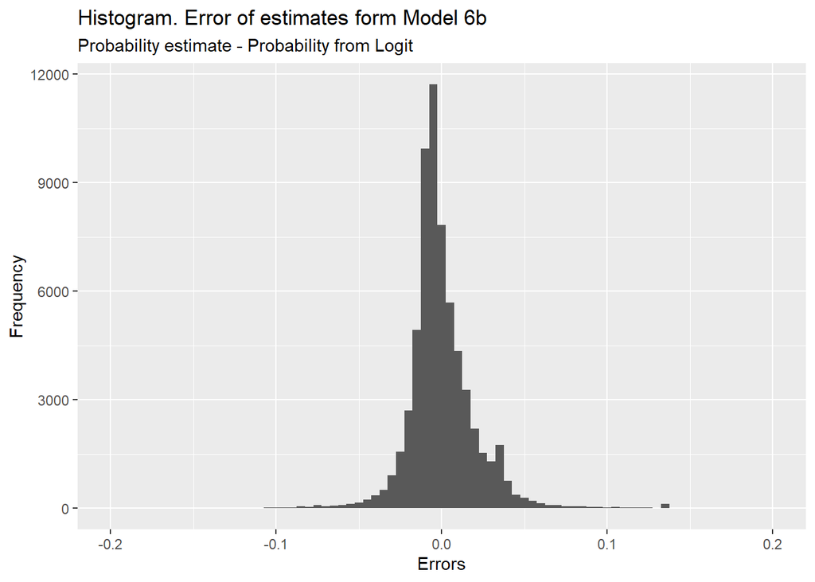

## Chapter 5: Predicting Match Winners

### Based on match stats (i.e., percentage of possession of the ball, number of shots, number of shots on target, being home team vs being visitor team, etc.), can we predict who the winner of a particular match was?

Match statistics are used as a metric to help determine and portray the performance of each team and the match as a whole to an audience. Compared to the wealth of data recorded by clubs on their teams player’s every match, these match summary statistics are very small, and it raises the question: do these match summary statistics paint an accurate picture of the game? If so, we should be able to predict the winner of a match most of the time just with these variables.

In order to predict the match winner based on the match summary variables, we decided to first reduce the number of variables by taking the difference between a certain stat for the two teams. This halved the number of variables to look at. This resulted in the data frame in table 3, where a positive value is in favor of team 1 while a negative value favors team 2. Ratios were not used because many of the values in some of the variables have a zero value, so taking the ratio often resulted in infinity, which is not a useful value in this instance.

Head

| winner | shot.dif | shot.target.dif | pass.dif | pass.acc.dif | possession.dif | corners.dif | offside.dif | foul.dif | yellow.dif | red.dif |
| --- | --- | --- | --- | --- | --- | --- | --- | --- | --- | --- |
| team1 | 20 | 6 | 347 | 12.48 | 0.53 | 5 | 4 | -3 | -1 | 0 |
| team1 | 6 | 1 | 558 | 23.06 | 19.31 | 7 | -5 | 3 | 2 | 0 |
| team1 | -6 | 0 | -209 | -5.21 | 0.89 | -3 | -1 | -7 | -2 | -1 |
| team2 | 3 | -3 | 97 | 7.59 | -4.83 | 3 | -2 | -12 | -2 | 0 |
| team2 | 2 | -2 | -201 | -7.45 | -4.61 | 1 | 4 | -3 | 0 | 0 |

**Table 3.** First five rows of match_difference data frame.

### 5.1 Developing Logistic Regression Model to Predict Match Winner

|  | winner |  |  | winner |  |  |
| --- | --- | --- | --- | --- | --- | --- |
| Predictors | Odds Ratios | CI | p | Odds Ratios | CI | p |
| (Intercept) | 0.98 | 0.89 – 1.09 | 0.767 | 0.98 | 0.88 – 1.09 | 0.688 |
| shot dif | 1.06 | 1.03 – 1.08 | **<0.001** | 1.05 | 1.03 – 1.08 | **<0.001** |
| shot target dif | 0.63 | 0.60 – 0.66 | **<0.001** | 0.63 | 0.60 – 0.66 | **<0.001** |
| pass dif | 1.00 | 1.00 – 1.00 | 0.462 |  |  |  |
| pass acc dif | 0.96 | 0.93 – 0.99 | **0.024** | 0.97 | 0.96 – 0.99 | **0.002** |
| possession dif | 1.01 | 0.99 – 1.02 | 0.266 |  |  |  |
| corners dif | 1.08 | 1.05 – 1.12 | **<0.001** | 1.09 | 1.06 – 1.13 | **<0.001** |
| offside dif | 0.98 | 0.93 – 1.02 | 0.277 |  |  |  |
| foul dif | 1.01 | 0.99 – 1.03 | 0.268 |  |  |  |
| yellow dif | 1.03 | 0.97 – 1.10 | 0.310 |  |  |  |
| red dif | 1.67 | 1.13 – 2.49 | **0.011** |  |  |  |
| Observations | 1941 |  |  | 1941 |  |  |
| R<sup>2</sup> Tjur | 0.278 |  |  | 0.273 |  |  |
| AIC | 2103.220 |  |  | 2103.534 |  |  |

Comparing model 1 and model 2 AIC values, they are found to be the same. Therefore, we decided to train and test model 2 as it has fewer variables but performs just as well as model 1.

### 5.2 Training and Testing our Match Winner Model

To train model 2, we created train and test data sets in 20-80 split of the match-diff data frame.

### 5.3 Assessing our Match Winner Model

Next, we analyzed the test results of model 2 by first making a confusion matrix, from which we could calculate the accuracy, which is 73%.

We finished by looking at the ROC plot of our test results and found the area under the curve (AUC) was found to be 0.804.

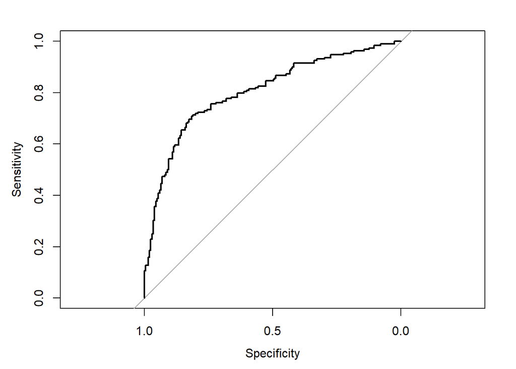

**Figure 3.** ROC plot showing test results of winner_model2.

## Chapter 6: Predicting Expected Goals

### Based on match stats (i.e., percentage of possession of the ball, number of shots, number of shots on target, etc.), can we predict the number of goals scored by each team?

### 6.1 Setting up Expected Goals Data Frame

In order to analyze the goals variable, we need to transform the data set from long to wide. This way, each match-team combination will have a corresponding # goals value stored in the same column.

The data set, teams, now has 3,882 records that can be used to analyze number of goals and the factors that influence it.

### 6.2 Developing a Linear Model to Predict Expected Goals

#### 6.2.1 Looking at Correlation Among Variables

To get an idea of correlations between the variables we can look at a correlation plot.

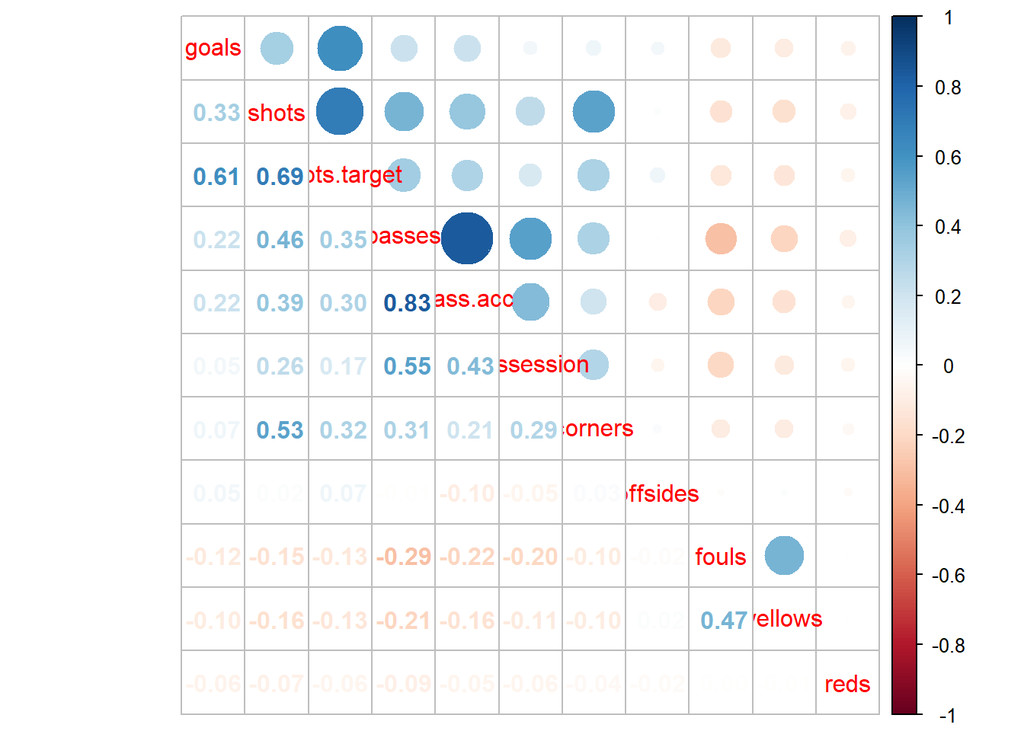

**Figure 4.** Mixed correlation plot.

#### 6.2.2 Model Feature Selection

We will run the linear regression model that is identified as the best model under Adjusted R squared and BIC criteria. For this exercise, we want to see, in general, whether or not the match statistics themselves explain the variation in number of goals. We are not currently interested in the difference between teams, so we will only keep continuous variables in the model.

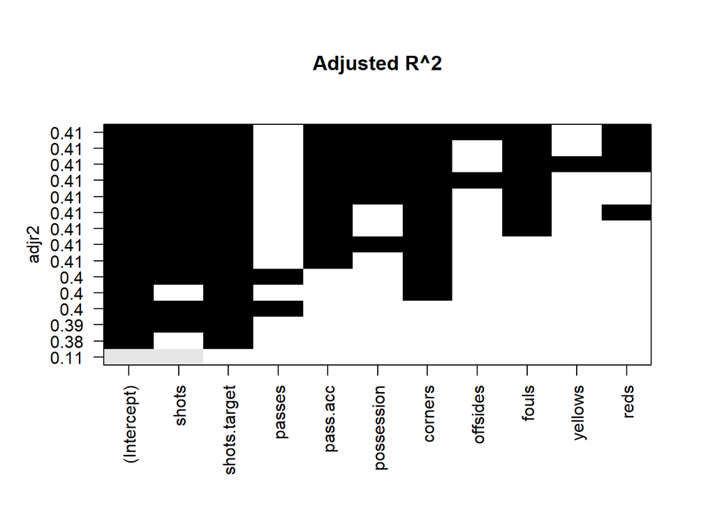

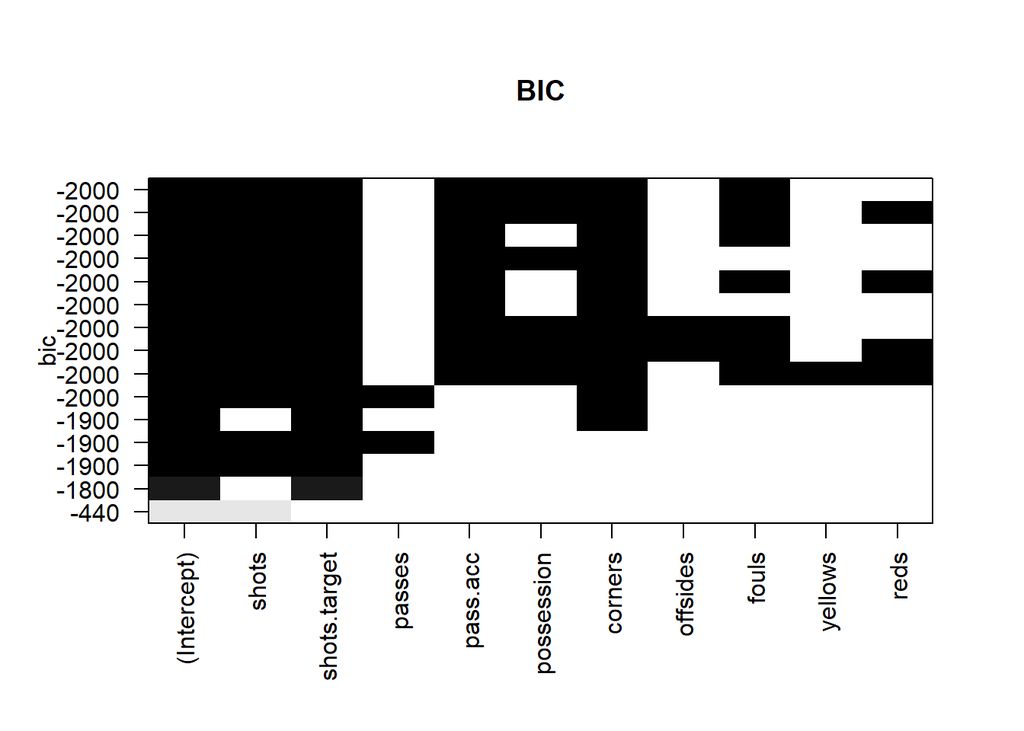

Standard Linear Regression

|  | Estimate | Std. Error | t value | Pr(>\|t\|) |
| --- | --- | --- | --- | --- |
| (Intercept) | -0.5054 | 0.2498 | -2.02 | 0.0431 |
| shots | -0.0344 | 0.0048 | -7.16 | 0.0000 |
| shots.target | 0.3497 | 0.0084 | 41.84 | 0.0000 |
| pass.acc | 0.0190 | 0.0031 | 6.05 | 0.0000 |
| possession | -0.0105 | 0.0031 | -3.35 | 0.0008 |
| corners | -0.0400 | 0.0062 | -6.41 | 0.0000 |
| fouls | -0.0122 | 0.0034 | -3.54 | 0.0004 |

#### 6.2.3 Training and Testing Linear Regression Model for Expected Goals

To train our linear regression model, we created train and test data sets in 20-80 split of the match-diff data frame. We analyzed the training results of our model looking at the residual values in the plots below.

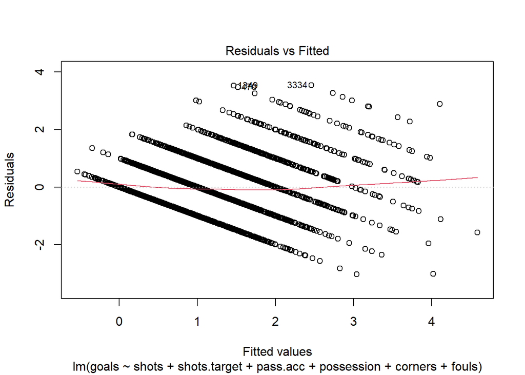

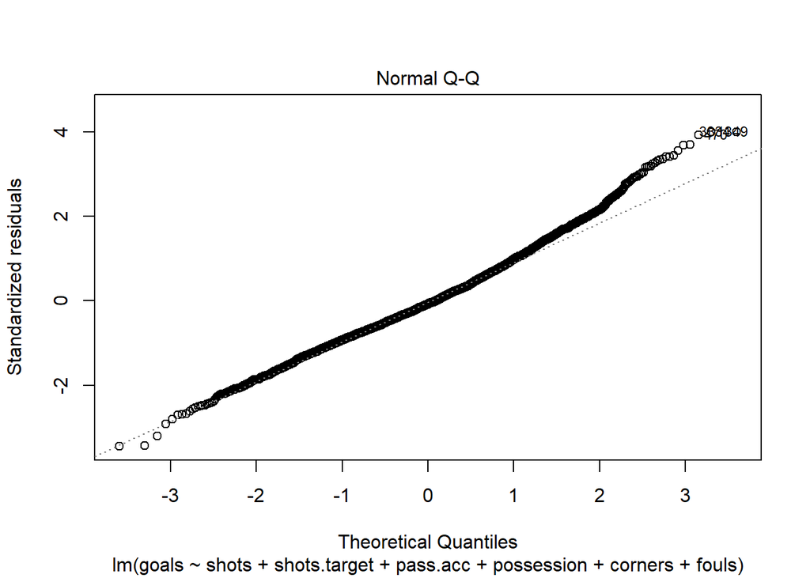

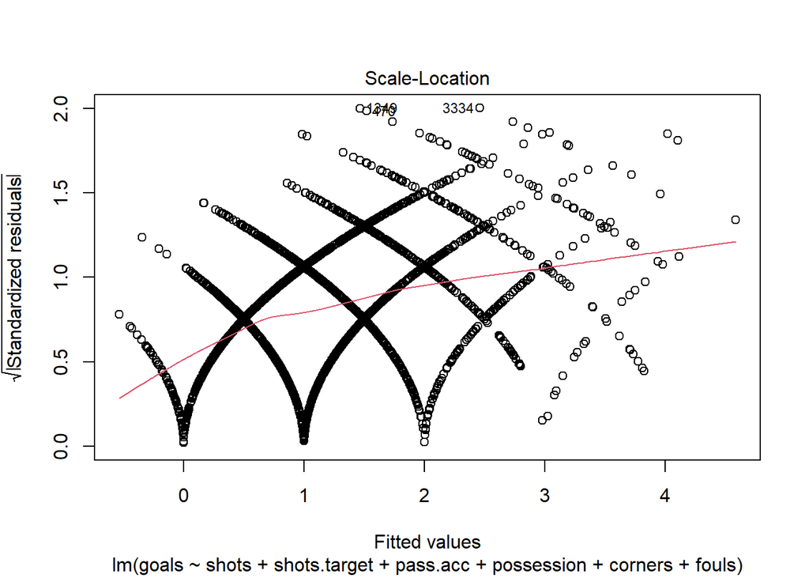

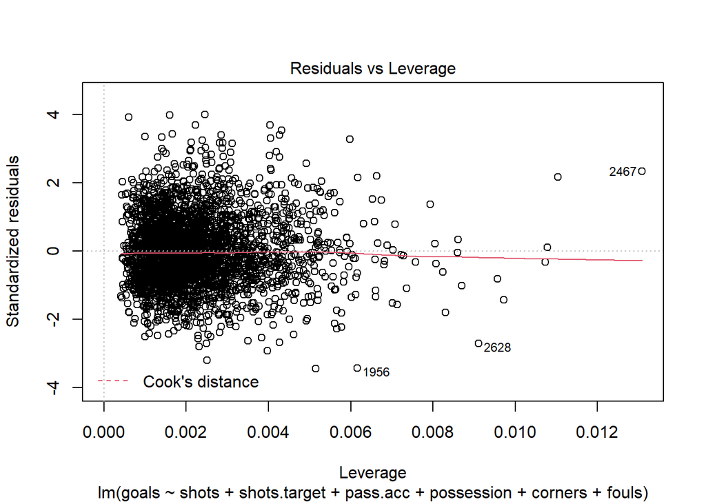

**Figure 5.** Plots showing the residuals of our model on the training data.

The first thing we notice is the pattern of diagonals in the top left plot. This is an effect of the fact that the dependent variable (# of goals) is a count variable rather than a continuous variable. Later in the report, we explore Poisson modeling, which is more appropriate for count data (Section 6.5).

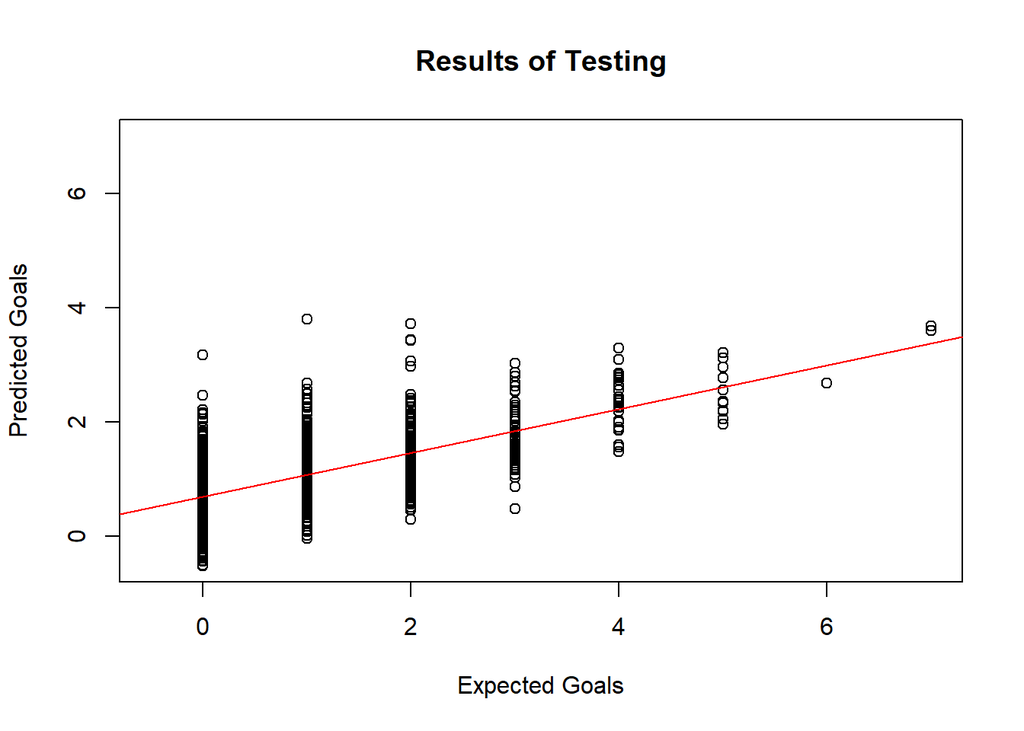

**Figure 6.** Predicted number of goals vs expected number of goals.

### 6.3 Developing a Logistical Regression Model to Predict Expected Goals

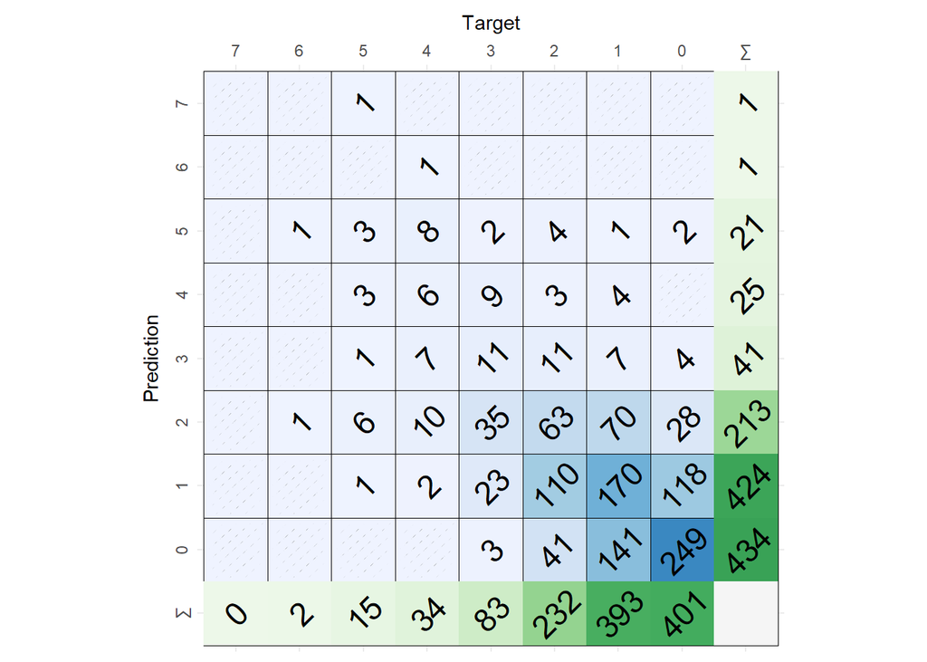

### 6.4 Using PCA/PCR to Predict Expected Goals

Returning to the concern that the linear regression model has a low R Squared value of 0.408, we want to see whether we can capture more variation in # goals by somehow incorporating the variables we left out of the linear regression. However, we are not inclined to simply throw those variables in due to the concern for multicollinearity (e.g. passes and pass accuracy are highly correlated as suggested by Figure 4). Instead, we may be able to incorporate such variables using PCA/PCR.

Table

|  | PC1 | PC2 | PC3 | PC4 | PC5 | PC6 | PC7 | PC8 | PC9 | PC10 | PC11 |
| --- | --- | --- | --- | --- | --- | --- | --- | --- | --- | --- | --- |
| goals | -0.2609 | 0.4444 | -0.2271 | 0.4388 | -0.0561 | 0.1616 | -0.3134 | 0.0470 | 0.5033 | 0.3274 | -0.0126 |
| shots | -0.4117 | 0.2871 | 0.0453 | -0.1687 | 0.1542 | -0.1977 | 0.2007 | -0.0448 | -0.4856 | 0.6110 | 0.0572 |
| shots.target | -0.3763 | 0.4697 | -0.1082 | 0.1163 | 0.0824 | -0.0141 | -0.0629 | 0.0244 | -0.3321 | -0.7005 | -0.0045 |
| passes | -0.4416 | -0.2599 | 0.1933 | 0.0842 | -0.0947 | 0.2318 | 0.2323 | -0.0312 | 0.0707 | -0.0194 | -0.7550 |
| pass.acc | -0.3981 | -0.2600 | 0.2287 | 0.2435 | -0.0490 | 0.2574 | 0.3995 | -0.0609 | 0.1472 | -0.0782 | 0.6345 |
| possession | -0.3062 | -0.3280 | 0.2806 | -0.1183 | -0.0438 | 0.0904 | -0.7447 | 0.2984 | -0.1879 | 0.0402 | 0.1237 |
| corners | -0.2906 | 0.1036 | 0.1705 | -0.5809 | 0.2191 | -0.3612 | -0.0111 | -0.0940 | 0.5748 | -0.1392 | 0.0326 |
| offsides | 0.0008 | 0.2286 | -0.1847 | -0.5808 | -0.4061 | 0.6314 | 0.0611 | 0.0605 | -0.0083 | 0.0246 | 0.0685 |
| fouls | 0.2205 | 0.3353 | 0.5527 | 0.0556 | 0.0650 | 0.0522 | 0.2132 | 0.6861 | 0.0721 | 0.0078 | -0.0451 |
| yellows | 0.1909 | 0.2761 | 0.6158 | 0.0538 | -0.0011 | 0.2107 | -0.1987 | -0.6465 | -0.0541 | 0.0131 | -0.0181 |
| reds | 0.0641 | -0.0713 | -0.1359 | -0.0657 | 0.8578 | 0.4798 | -0.0247 | 0.0169 | 0.0024 | 0.0209 | -0.0240 |

**Table 5.** Displays the contribution of each variable to each PC.

#### 6.4.1 Developing PCR Model for Predicting Expected Goals

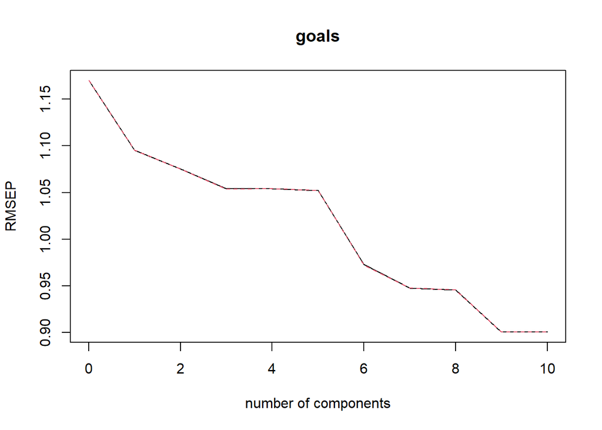

**Figure 7.** Shows RMSEP vs number of PC components.

We tested a full PC model, that used all PCs in the PCR. The result of this model is shown below.

Full model using Principal Comps

|  | Estimate | Std. Error | t value | Pr(>\|t\|) |
| --- | --- | --- | --- | --- |
| (Intercept) | 1.1558 | 0.0144 | 80.093 | 0.000 |
| PC1 | -0.2281 | 0.0080 | -28.585 | 0.000 |
| PC2 | 0.1825 | 0.0124 | 14.700 | 0.000 |
| PC3 | -0.1931 | 0.0132 | -14.677 | 0.000 |
| PC4 | 0.0023 | 0.0144 | 0.159 | 0.874 |
| PC5 | 0.0720 | 0.0149 | 4.837 | 0.000 |
| PC6 | -0.4534 | 0.0164 | -27.727 | 0.000 |
| PC7 | -0.3009 | 0.0196 | -15.346 | 0.000 |
| PC8 | -0.0906 | 0.0201 | -4.500 | 0.000 |
| PC9 | -0.5702 | 0.0285 | -20.011 | 0.000 |
| PC10 | 0.0330 | 0.0383 | 0.861 | 0.389 |

Limited model using Principal Comps

|  | Estimate | Std. Error | t value | Pr(>\|t\|) |
| --- | --- | --- | --- | --- |
| (Intercept) | 1.156 | 0.0162 | 71.2 | 0 |
| PC1 | -0.228 | 0.0090 | -25.4 | 0 |
| PC2 | 0.182 | 0.0140 | 13.1 | 0 |
| PC7 | -0.301 | 0.0220 | -13.7 | 0 |
| PC9 | -0.570 | 0.0320 | -17.8 | 0 |

The variables that contribute most to each of the PC’s included in the limited model are the following:

1. PC1: shots and passes
2. PC2: shots.target and fouls
3. PC7: possession and pass.acc
4. PC9: corners and shots

### 6.5 Poisson Modelling for Count Data

Returning to the idea that Poisson modelling might be more appropriate in analyzing number of goals due to its non-negative count nature, we use the glm() function instead of the lm() function on the best models we identified under linear regression and PCR settings above.

```
##
## Call:
## glm(formula = goals ~ shots + shots.target + pass.acc + possession +
##     corners + fouls, family = "poisson", data = teams_cont)
##
## Deviance Residuals:
##     Min       1Q   Median       3Q      Max
## -2.9661  -1.0547  -0.0573   0.4911   2.5347
##
## Coefficients:
##              Estimate Std. Error z value Pr(>|z|)
## (Intercept)  -1.21227    0.27258   -4.45  8.7e-06 ***
## shots        -0.02620    0.00490   -5.35  8.9e-08 ***
## shots.target  0.24899    0.00776   32.10  < 2e-16 ***
## pass.acc      0.01545    0.00341    4.53  5.9e-06 ***
## possession   -0.00962    0.00331   -2.91   0.0037 **
## corners      -0.03319    0.00645   -5.15  2.6e-07 ***
## fouls        -0.00843    0.00367   -2.30   0.0216 *
## ---
## Signif. codes:  0 '***' 0.001 '**' 0.01 '*' 0.05 '.' 0.1 ' ' 1
##
## (Dispersion parameter for poisson family taken to be 1)
##
##     Null deviance: 5051.8  on 3881  degrees of freedom
## Residual deviance: 3414.4  on 3875  degrees of freedom
## AIC: 9509
##
## Number of Fisher Scoring iterations: 5
```

Standard Poisson Regression

|  | Estimate | Std. Error | z value | Pr(>\|z\|) |
| --- | --- | --- | --- | --- |
| (Intercept) | -1.2123 | 0.2726 | -4.45 | 0.0000 |
| shots | -0.0262 | 0.0049 | -5.35 | 0.0000 |
| shots.target | 0.2490 | 0.0078 | 32.10 | 0.0000 |
| pass.acc | 0.0155 | 0.0034 | 4.53 | 0.0000 |
| possession | -0.0096 | 0.0033 | -2.91 | 0.0037 |
| corners | -0.0332 | 0.0064 | -5.15 | 0.0000 |
| fouls | -0.0084 | 0.0037 | -2.30 | 0.0216 |

## Chapter 7: Conclusions